## Omri Kireev - עומרי קירייב

## 319129326

## https://www.kaggle.com/remotok

# Some info about this competition

## In this competition we are trying to create a model to predict whether or not a person survived in the titanic based on some features such as age, gender etc.

### In this task I'll be using logistic regression model.

### I'll start with reading the train and test data from the csv

```python
import numpy as np # linear algebra
import pandas as pd # data processing, CSV file I/O (e.g. pd.read_csv)
import math

#I worked from google's colab thus this path to the files
train_data = pd.read_csv("./train.csv")
test_data = pd.read_csv("./test.csv")
#train_data = pd.read_csv("/kaggle/input/titanic/train.csv")
#test_data = pd.read_csv("/kaggle/input/titanic/test.csv")
```

### Checking colums data types

#### I see that most of the columns are numbers but some like name | sex | cabin | embarked are actually strings so I'll have to transform those columns.

```python
train_data.dtypes
```

```
PassengerId      int64
Survived         int64
Pclass           int64
Name            object
Sex             object
Age            float64
SibSp            int64
Parch            int64
Ticket          object
Fare           float64
Cabin           object
Embarked        object
dtype: object
```

### I notice that there are few columns with missing data

### I will have to decide what to do with those columns(The easiest way is to drop those but maybe imputation will give my model a better prediction power)

```python
pd.set_option('max_columns', None)
print("Checking any missing data in train \n", train_data.isna().any())
print("\n\nShow summary of all train \n", train_data.describe(include = 'all'))
print("-----------------")
print("Checking any missing data in test \n",test_data.isna().any())
print("\n\nShow summary of all test \n", test_data.describe(include = 'all'))
train_data.head()
```

```
Checking any missing data in train
 PassengerId    False
Survived       False
Pclass         False
Name           False
Sex            False
Age             True
SibSp          False
Parch          False
Ticket         False
Fare           False
Cabin           True
Embarked        True
dtype: bool


Show summary of all train
         PassengerId    Survived      Pclass  \
count    891.000000  891.000000  891.000000
unique          NaN         NaN         NaN
top             NaN         NaN         NaN
freq            NaN         NaN         NaN
mean     446.000000    0.383838    2.308642
std      257.353842    0.486592    0.836071
min        1.000000    0.000000    1.000000
25%      223.500000    0.000000    2.000000
50%      446.000000    0.000000    3.000000
75%      668.500000    1.000000    3.000000
max      891.000000    1.000000    3.000000

                                                     Name   Sex         Age  \
count                                                 891   891  714.000000
unique                                                891     2         NaN
top     Van Impe, Mrs. Jean Baptiste (Rosalie Paula Go...  male         NaN
freq                                                    1   577         NaN
mean                                                  NaN   NaN   29.699118
std                                                   NaN   NaN   14.526497
min                                                   NaN   NaN    0.420000
25%                                                   NaN   NaN   20.125000
50%                                                   NaN   NaN   28.000000
```

[output cut: 42 more lines]

```
75%     1204.750000    3.000000                        NaN   NaN   39.000000
max     1309.000000    3.000000                        NaN   NaN   76.000000

             SibSp       Parch    Ticket        Fare            Cabin Embarked
count   418.000000  418.000000       418  417.000000               91      418
unique         NaN         NaN       363         NaN               76        3
top            NaN         NaN  PC 17608         NaN  B57 B59 B63 B66        S
freq           NaN         NaN         5         NaN                3      270
mean      0.447368    0.392344       NaN   35.627188              NaN      NaN
std       0.896760    0.981429       NaN   55.907576              NaN      NaN
min       0.000000    0.000000       NaN    0.000000              NaN      NaN
25%       0.000000    0.000000       NaN    7.895800              NaN      NaN
50%       0.000000    0.000000       NaN   14.454200              NaN      NaN
75%       1.000000    0.000000       NaN   31.500000              NaN      NaN
max       8.000000    9.000000       NaN  512.329200              NaN      NaN
```

|  | PassengerId | Survived | Pclass | Name | Sex | Age | SibSp | Parch | Ticket | Fare | Cabin | Embarked |
| --- | --- | --- | --- | --- | --- | --- | --- | --- | --- | --- | --- | --- |
| 0 | 1 | 0 | 3 | Braund, Mr. Owen Harris | male | 22.0 | 1 | 0 | A/5 21171 | 7.2500 | NaN | S |
| 1 | 2 | 1 | 1 | Cumings, Mrs. John Bradley (Florence Briggs Th... | female | 38.0 | 1 | 0 | PC 17599 | 71.2833 | C85 | C |
| 2 | 3 | 1 | 3 | Heikkinen, Miss. Laina | female | 26.0 | 0 | 0 | STON/O2. 3101282 | 7.9250 | NaN | S |
| 3 | 4 | 1 | 1 | Futrelle, Mrs. Jacques Heath (Lily May Peel) | female | 35.0 | 1 | 0 | 113803 | 53.1000 | C123 | S |
| 4 | 5 | 0 | 3 | Allen, Mr. William Henry | male | 35.0 | 0 | 0 | 373450 | 8.0500 | NaN | S |

### I can see that the "Cabin" column has a lot of missing values -- only 204 rows from 891 total rows in train dataframe and only 91/418 in test dataframe

#### I'm not sure what does this "Cabin" column mean so I'll refer to kaggle's data dictionary

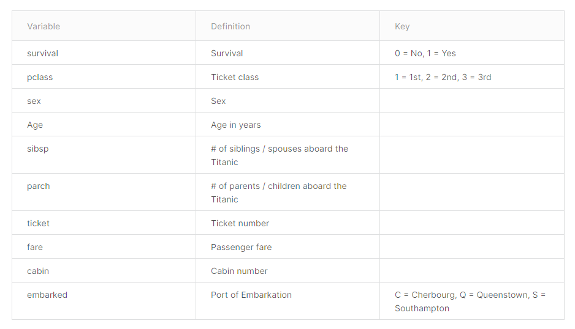

#### I think this data might be important but I'm not sure how would I impute all those missing data, for now, I'll choose to drop this column if I have time I'll try and create a model that includes this column

#### Apart from this column I notice the "Name" column, maybe people rushed to save people with important names I don't exclude this possibility but I think that for most of the cases names had less importance to the survivability of the person so I'll drop this column too.

```python
train_data = train_data.drop(['Name','Cabin','PassengerId'], axis=1)
test_passengerID = test_data['PassengerId']
test_data = test_data.drop(['Name','Cabin','PassengerId'], axis=1)
train_data.dtypes
```

```
Survived      int64
Pclass        int64
Sex          object
Age         float64
SibSp         int64
Parch         int64
Ticket       object
Fare        float64
Embarked     object
dtype: object
```

#### I try to see correlation between the numeric columns to "Survived" target

#### The highest correlation I can see is between Pclass and "Survived" though it's only at 0.34 which seems quite low compared to the example we saw at class with columns that had much higher correlation to the target.

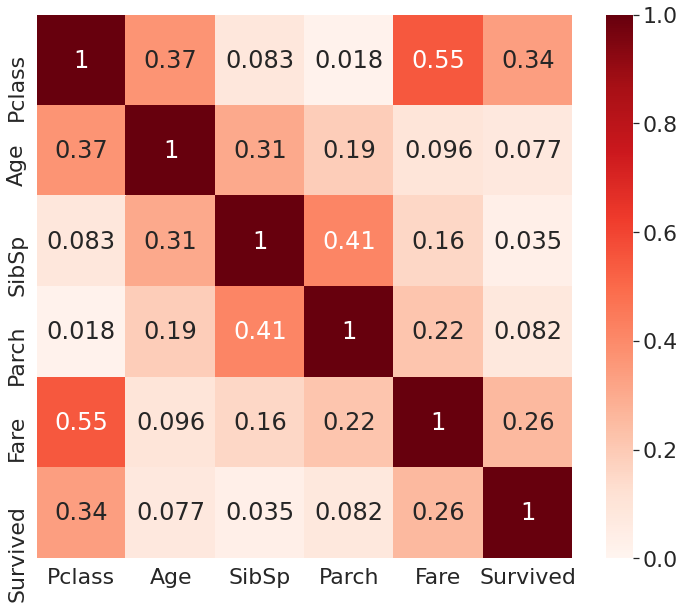

```python
import seaborn as sns
import matplotlib.pyplot as plt

train_data_cp = train_data.drop("Survived", axis=1)
train_data_cp["Survived"] = train_data["Survived"]
plt.figure(figsize=(12,10))
cor = np.abs(train_data_cp.corr())
sns.heatmap(cor, annot=True, cmap=plt.cm.Reds, vmin=0, vmax=1)
plt.show()
```

## It seems like women have a higher % of surviving

```
% of women who survived: 74.20382165605095
% of men who survived: 18.890814558058924
```

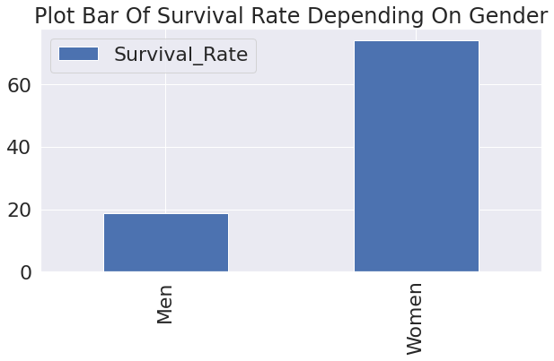

```python
women = train_data.loc[train_data.Sex == 'female']["Survived"]
rate_women = sum(women)/len(women) * 100

print("% of women who survived:", rate_women)

men = train_data.loc[train_data.Sex == 'male']["Survived"]
rate_men = sum(men)/len(men) * 100

print("% of men who survived:", rate_men)

df = pd.DataFrame({"Survival_Rate": [rate_men, rate_women]}, index=["Men", "Women"])
df.plot(kind="bar")
plt.title('Plot Bar Of Survival Rate Depending On Gender')
plt.show()
```

## Higher class have a higher % of surviving

##### It makes sense as females and higher class were given priority to board the safety boats

```
% of class1 who survived: 62.96296296296296
% of class1 who survived: 47.28260869565217
% of class1 who survived: 24.236252545824847
```

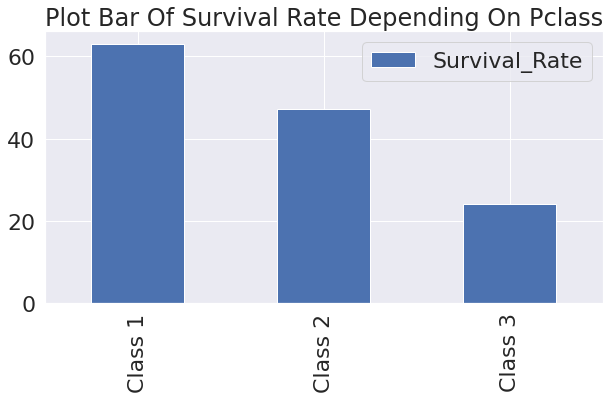

```python
class1 = train_data.loc[train_data.Pclass == 1]["Survived"]
rate_class1 = sum(class1)/len(class1) * 100

print("% of class1 who survived:", rate_class1)

class2 = train_data.loc[train_data.Pclass == 2]["Survived"]
rate_class2 = sum(class2)/len(class2) * 100

print("% of class1 who survived:", rate_class2)

class3 = train_data.loc[train_data.Pclass == 3]["Survived"]
rate_class3 = sum(class3)/len(class3) * 100

print("% of class1 who survived:", rate_class3)

df = pd.DataFrame({"Survival_Rate": [rate_class1, rate_class2, rate_class3]}, index=["Class 1", "Class 2", "Class 3"])
df.plot(kind="bar")
plt.title('Plot Bar Of Survival Rate Depending On Pclass')
plt.show()
```

## I'm not sure why different port embarked has better % survival rate, maybe they were closer to safety boats?

```
% of embarked from Q who survived: 38.961038961038966
% of embarked from C who survived: 55.35714285714286
% of embarked from S who survived: 33.69565217391305
```

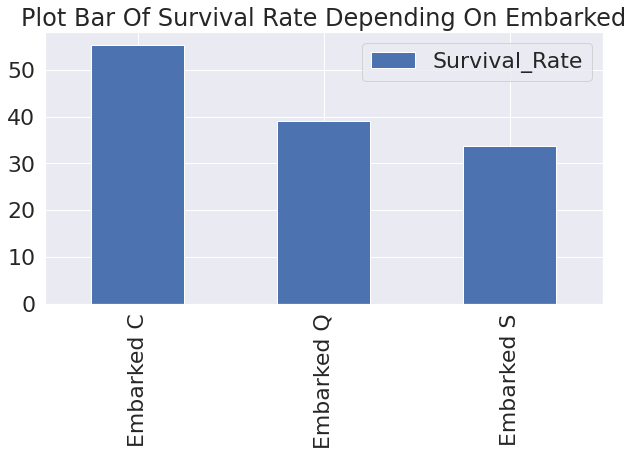

```python
embarkedQ = train_data.loc[train_data.Embarked == 'Q']["Survived"]
rate_embarkedQ = sum(embarkedQ)/len(embarkedQ) * 100

print("% of embarked from Q who survived:", rate_embarkedQ)

embarkedC = train_data.loc[train_data.Embarked == 'C']["Survived"]
rate_embarkedC = sum(embarkedC)/len(embarkedC) * 100

print("% of embarked from C who survived:", rate_embarkedC)

embarkedS = train_data.loc[train_data.Embarked == 'S']["Survived"]
rate_embarkedS = sum(embarkedS)/len(embarkedS) * 100

print("% of embarked from S who survived:", rate_embarkedS)

df = pd.DataFrame({"Survival_Rate": [rate_embarkedC, rate_embarkedQ, rate_embarkedS]}, index=["Embarked C", "Embarked Q", "Embarked S"])
df.plot(kind="bar")
plt.title('Plot Bar Of Survival Rate Depending On Embarked')
plt.show()
```

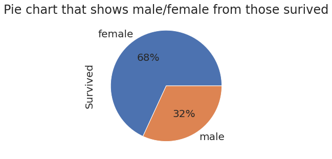

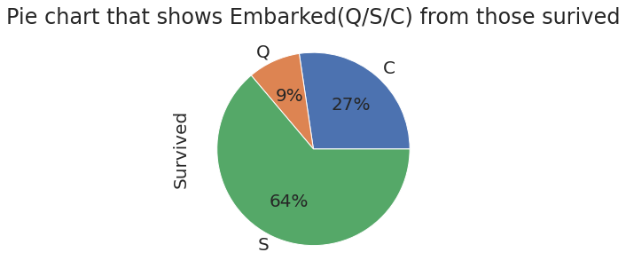

```python
# define plt settings
plt.rcParams["font.size"] = 20
plt.rcParams["axes.labelsize"] = 20
plt.rcParams["xtick.labelsize"] = 20
plt.rcParams["ytick.labelsize"] = 20
plt.rcParams["legend.fontsize"] = 20
plt.rcParams["figure.figsize"] = (10,5)

plt.title('Pie chart that shows male/female from those surived')
pieData = train_data.groupby("Sex")["Survived"].sum()
pieData.plot.pie(autopct='%1.0f%%')
plt.show()
plt.title('Pie chart that shows Embarked(Q/S/C) from those surived')
pieData = train_data.groupby("Embarked")["Survived"].sum()
pieData.plot.pie(autopct='%1.0f%%')
plt.show()
```

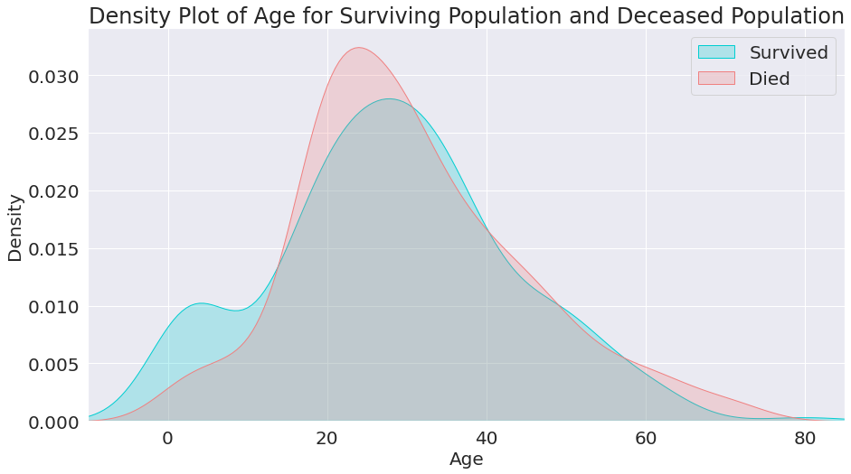

```python
plt.figure(figsize=(15,8))
ax = sns.kdeplot(train_data["Age"][train_data.Survived == 1], color="darkturquoise", shade=True)
sns.kdeplot(train_data["Age"][train_data.Survived == 0], color="lightcoral", shade=True)
plt.legend(['Survived', 'Died'])
plt.title('Density Plot of Age for Surviving Population and Deceased Population')
ax.set(xlabel='Age')
plt.xlim(-10,85)
plt.show()
```

### The age distribution for survivors and deceased is actually very similar. One notable difference is that, of the survivors, a larger proportion were children. The passengers evidently made an attempt to save children by giving them a place on the life rafts.

# Building a model

### I tried in my task both MLP and Linear regression, Aviad went over MLP with us but we didn't learn it with Gadi so I felt more familiar with linear regression, I didn't take neural networks course this semester so I'm not sure about how it works and why and when is it better than linear regression.

```python
from sklearn import neural_network
from sklearn.compose import ColumnTransformer
from sklearn.pipeline import Pipeline
from sklearn.impute import SimpleImputer
from sklearn.preprocessing import OneHotEncoder
from sklearn.preprocessing import StandardScaler
from sklearn import linear_model
import sklearn

def createPipeLine(X, model):
  # Preprocessing for numerical data
  numerical_transformer = SimpleImputer(strategy='median')

  # Preprocessing for categorical data
  categorical_transformer = Pipeline(steps=[
      ('imputer', SimpleImputer(strategy='most_frequent')),
      ('onehot', OneHotEncoder(handle_unknown='ignore'))
  ])


  numerical_cols = [cname for cname in X.columns if X[cname].dtype in ['int64', 'float64']]
  categorical_cols = [cname for cname in X.columns if X[cname].nunique() < 10 and
                      X[cname].dtype == "object"]


  # Bundle preprocessing for numerical and categorical data
  preprocessor = ColumnTransformer(
      transformers=[
          ('num', numerical_transformer, numerical_cols),
          ('cat', categorical_transformer, categorical_cols)
      ])

  #model = linear_model.SGDClassifier(loss='log', alpha=0, learning_rate='constant', eta0=0.01)


  my_pipeline = Pipeline(steps=[('preprocessor', preprocessor),
                                ('Scaler', StandardScaler()),
                                ('model', model)
                              ])
  return my_pipeline
```

```python
t = train_data["Survived"]
X = train_data.drop(labels=['Survived'],axis=1)
X_train, X_validation, t_train, t_validation = sklearn.model_selection.train_test_split(X, t, test_size=0.2, random_state=2)

model = linear_model.SGDClassifier(loss='log', alpha=0, learning_rate='constant', eta0=0.01)
my_pipeline = createPipeLine(X_train, model)
my_pipeline.fit(X_train, t_train)
print('Accuracy score on train', my_pipeline.score(X_train, t_train))
print('Accuracy score on validation', my_pipeline.score(X_validation, t_validation))
preds = my_pipeline.predict(test_data)
output = pd.DataFrame({'PassengerId': test_passengerID, 'Survived': preds})
output.to_csv('my_submission.csv', index=False)
print("Submission CSV was successfully saved!")
```

```
Accuracy score on train 0.8075842696629213
Accuracy score on validation 0.7821229050279329
Submission CSV was successfully saved!
```

## Created pipeline with this basic steps -- imputing + one hot encoding

## I saved the predictions made with this model to see how good am I doing currently, that was my first submission that scored 77%

### In class we learned that we can create new features using existing columns, for example I might say that maybe there's correlation between a person's length of name and whether or not he survived though it is unlikely that there's really correlation here.

### In my opinion I can create a new feature age^2 as I believe it should fit

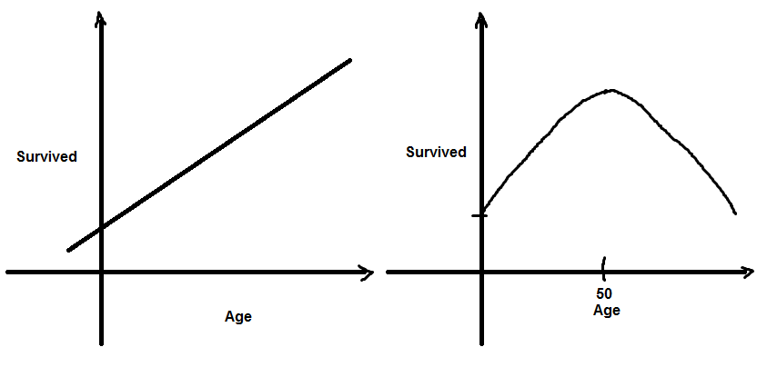

```python
import math
train_data_cp = train_data.copy()
train_data_cp["ageSquared"] = train_data_cp["Age"] ** 2
test_data_cp = test_data.copy()
test_data_cp["ageSquared"] = test_data_cp["Age"] ** 2

t = train_data_cp["Survived"]
X = train_data_cp.drop(labels=['Survived'],axis=1)
X_train, X_validation, t_train, t_validation = sklearn.model_selection.train_test_split(X, t, test_size=0.2, random_state=2)

my_pipeline2 = createPipeLine(X_train, model)
my_pipeline2.fit(X_train, t_train)
print('Accuracy score on train', my_pipeline2.score(X_train, t_train))
print('Accuracy score on validation', my_pipeline2.score(X_validation, t_validation))
preds = my_pipeline2.predict(test_data_cp)
output = pd.DataFrame({'PassengerId': test_passengerID, 'Survived': preds})
output.to_csv('my_submission2.csv', index=False)
print("Submission CSV was successfully saved!")
```

```
Accuracy score on train 0.8075842696629213
Accuracy score on validation 0.7653631284916201
Submission CSV was successfully saved!
```

### Apparently this did not work/help to my accuracy, either I did something bad with it or this feature is not helpful so for now I'll go back to the first model but first I'll try MLP.

```python
t = train_data["Survived"]
X = train_data.drop(labels=['Survived'],axis=1)
X_train, X_validation, t_train, t_validation = sklearn.model_selection.train_test_split(X, t, test_size=0.2, random_state=2)

model2 = neural_network.MLPClassifier(activation='logistic', solver='sgd', alpha=0, max_iter=10000)
my_pipeline3 = createPipeLine(X_train, model2)
my_pipeline3.fit(X_train, t_train)
print('Accuracy score on train', my_pipeline3.score(X_train, t_train))
print('Accuracy score on validation', my_pipeline3.score(X_validation, t_validation))
preds = my_pipeline3.predict(test_data)
output = pd.DataFrame({'PassengerId': test_passengerID, 'Survived': preds})
output.to_csv('my_submission3.csv', index=False)
print("Submission CSV was successfully saved!")
```

```
Accuracy score on train 0.7991573033707865
Accuracy score on validation 0.7541899441340782
Submission CSV was successfully saved!
```

## Hyper paramter tuning

### I tried to change two parameters in my model and see scores

```python
'''

from sklearn import metrics
alpha = [0,1e-4, 1e-3, 1e-2, 1e-1, 1e0]
eta = [0.003,0.006,0.009,0.012,0.015,0.018,0.021,0.024,0.027,0.03]
t = train_data["Survived"]
X = train_data.drop(labels=['Survived'],axis=1)
X_train, X_validation, t_train, t_validation = sklearn.model_selection.train_test_split(X, t, test_size=0.2, random_state=2)
best_et = 0
best_alp = 0
best_acc = 0
for alp in alpha:
  for et in eta:
    model = linear_model.SGDClassifier(loss='log', alpha=alp, learning_rate='constant',random_state=5, eta0=et)
    my_pipeline = createPipeLine(X_train, model)
    my_pipeline.fit(X_train, t_train)
    y_train_prob = my_pipeline.predict_proba(X_train)
    y_validation_prob = my_pipeline.predict_proba(X_validation)
    print('Alpha:',alp, " ETA0:", et)
    score = my_pipeline.score(X_validation, t_validation)
    if score > best_acc:
      best_et = et
      best_alp = alp
      best_acc = score
    print('Accuracy score on train', my_pipeline.score(X_train, t_train))
    print('Accuracy score on validation', my_pipeline.score(X_validation, t_validation))
    print('CE on train', metrics.log_loss(t_train, y_train_prob))
    print('CE on validation', metrics.log_loss(t_validation, y_validation_prob))
    print("\n--------\n")
print("Best ", best_acc, " Alp ", best_alp, " et ", best_et)
'''
print()
```

# I want to train my linear model with all of my training data maybe I'll get a better score with that

```python
model = linear_model.SGDClassifier(loss='log', alpha=0, learning_rate='constant',random_state=2, eta0=0.03)
my_pipeline = createPipeLine(X, model)
my_pipeline.fit(X, t)
print('Accuracy score on train', my_pipeline.score(X, t))
preds = my_pipeline.predict(test_data)
output = pd.DataFrame({'PassengerId': test_passengerID, 'Survived': preds})
output.to_csv('my_submission_allData.csv', index=False)
print("Submission CSV was successfully saved!")
```

```
Accuracy score on train 0.8035914702581369
Submission CSV was successfully saved!
```

# Now that I had my test with how to create models myself I'll redo the task. I wasn't sure whether or not to keep my first trial but as was written in the task's description I decided to keep it to show my progress.

# Step 1 - read the data

```python
train_data = pd.read_csv("./train.csv")
test_data = pd.read_csv("./test.csv")
passengerID_forSubmission = test_data["PassengerId"]
print("Done reading data")
```

```
Done reading data
```

# Step 2 - impute missing values

## Training data - total of 891 rows.

- Embarked 2 missing values
- Age 177 missing values

## Testing data - total of 418 rows.

- Fare 1 missing values
- Age 86 missing values

#### As I was imputing a high % of values in the Age column I decided to add age_was_missing column in hope that it'd help my model

##### I chose to drop name & cabin & ticket columns

- cabin was dropped for a lot of missing values
- name was dropped because I thought name was less likely to affect whether or not someone survived
- ticket was dropped as I thought they were a arbitrarily assigned numbers

```python
# drop passengerID column + cabin column
survived_result = train_data["Survived"]
train_data = train_data.drop(['PassengerId', 'Cabin', 'Name', 'Ticket', 'Survived'],axis=1)
test_data = test_data.drop(['PassengerId','Cabin', 'Name', 'Ticket'],axis=1)

#Impute training data:
#Embarked
train_data['Embarked'].fillna(train_data['Embarked'].value_counts().idxmax(), inplace = True)
#Age
train_data['Age_Was_Missing'] = train_data['Age'].isna().map({False:0.0,True:1.0})
train_data['Age'].fillna(train_data['Age'].mean(), inplace = True)

#Impute Testing Data:
#Fare
test_data['Fare'].fillna(test_data['Fare'].mean(), inplace = True)
#Age
test_data['Age_Was_Missing'] = test_data['Age'].isna().map({False:0.0,True:1.0})
test_data['Age'].fillna(test_data['Age'].mean(), inplace = True)

print("Done imputing data")
```

```
Done imputing data
```

```python
print(train_data.isna().any())
print("-------------")
print(test_data.isna().any())
print("-------------")
print(train_data.dtypes)
```

```
Pclass             False
Sex                False
Age                False
SibSp              False
Parch              False
Fare               False
Embarked           False
Age_Was_Missing    False
dtype: bool
-------------
Pclass             False
Sex                False
Age                False
SibSp              False
Parch              False
Fare               False
Embarked           False
Age_Was_Missing    False
dtype: bool
-------------
Pclass               int64
Sex                 object
Age                float64
SibSp                int64
Parch                int64
Fare               float64
Embarked            object
Age_Was_Missing    float64
dtype: object
```

# Step 3 - Transform Catergorical Columns using One Hot Encoding

```python
from sklearn.preprocessing import OneHotEncoder

encoder = None


def doOHE(df, cols):
  global encoder
  if encoder is None:
    OH_encoder = OneHotEncoder(handle_unknown='ignore', sparse=False)
    OH_encoder = OH_encoder.fit(df[cols])
    encoder = OH_encoder
  OH_cols = pd.DataFrame(encoder.transform(df[cols]))
  OH_cols.columns = encoder.get_feature_names(cols)
  OH_cols.index = df.index

  df = df.drop(cols,axis=1)
  df = pd.concat([df, OH_cols],axis=1)
  return df

train_data = doOHE(train_data,['Sex','Embarked'])
test_data = doOHE(test_data,['Sex','Embarked'])

print("Done One Hot Encoding")
```

```
Done One Hot Encoding
```

# Step 4 - Adding features

- I'd like to add some features I find to be reasonable, from one of the graphs I found that kids are more likely to survived so I'll add "is_underage" feature
- I'll add two more features relating to family:
  - Total family size (sum of SibSp and Parch)
  - Is Alone
- Added Age_Was_missing column further at step 2
- Additionally I'd like to add Age^2 feature

```python
def addFeatures(df):
  df["Underage"] = (df['Age'] < 18).map({False:0.0,True:1.0})
  df["TotalFamily"] = df['SibSp'] + df['Parch']
  df['IsAlone'] = (df['TotalFamily'] == 0).map({False:0.0,True:1.0})
  df['Age_Squared'] = df['Age']**2
  return df

train_data = addFeatures(train_data)
test_data = addFeatures(test_data)
print("Done Adding Features")
```

```
Done Adding Features
```

```python
train_data
```

|  | Pclass | Age | SibSp | Parch | Fare | Age_Was_Missing | Sex_female | Sex_male | Embarked_C | Embarked_Q | Embarked_S | Underage | TotalFamily | IsAlone | Age_Squared |
| --- | --- | --- | --- | --- | --- | --- | --- | --- | --- | --- | --- | --- | --- | --- | --- |
| 0 | 3 | 22.000000 | 1 | 0 | 7.2500 | 0.0 | 0.0 | 1.0 | 0.0 | 0.0 | 1.0 | 0.0 | 1 | 0.0 | 484.000000 |
| 1 | 1 | 38.000000 | 1 | 0 | 71.2833 | 0.0 | 1.0 | 0.0 | 1.0 | 0.0 | 0.0 | 0.0 | 1 | 0.0 | 1444.000000 |
| 2 | 3 | 26.000000 | 0 | 0 | 7.9250 | 0.0 | 1.0 | 0.0 | 0.0 | 0.0 | 1.0 | 0.0 | 0 | 1.0 | 676.000000 |
| 3 | 1 | 35.000000 | 1 | 0 | 53.1000 | 0.0 | 1.0 | 0.0 | 0.0 | 0.0 | 1.0 | 0.0 | 1 | 0.0 | 1225.000000 |
| 4 | 3 | 35.000000 | 0 | 0 | 8.0500 | 0.0 | 0.0 | 1.0 | 0.0 | 0.0 | 1.0 | 0.0 | 0 | 1.0 | 1225.000000 |
| ... | ... | ... | ... | ... | ... | ... | ... | ... | ... | ... | ... | ... | ... | ... | ... |
| 886 | 2 | 27.000000 | 0 | 0 | 13.0000 | 0.0 | 0.0 | 1.0 | 0.0 | 0.0 | 1.0 | 0.0 | 0 | 1.0 | 729.000000 |
| 887 | 1 | 19.000000 | 0 | 0 | 30.0000 | 0.0 | 1.0 | 0.0 | 0.0 | 0.0 | 1.0 | 0.0 | 0 | 1.0 | 361.000000 |
| 888 | 3 | 29.699118 | 1 | 2 | 23.4500 | 1.0 | 1.0 | 0.0 | 0.0 | 0.0 | 1.0 | 0.0 | 3 | 0.0 | 882.037589 |
| 889 | 1 | 26.000000 | 0 | 0 | 30.0000 | 0.0 | 0.0 | 1.0 | 1.0 | 0.0 | 0.0 | 0.0 | 0 | 1.0 | 676.000000 |
| 890 | 3 | 32.000000 | 0 | 0 | 7.7500 | 0.0 | 0.0 | 1.0 | 0.0 | 1.0 | 0.0 | 0.0 | 0 | 1.0 | 1024.000000 |

891 rows × 15 columns

# Step 5 - Scaling The Data Before Model

```python
from sklearn.preprocessing import StandardScaler

scaler = None


def doScale(df):
  global scaler
  if scaler is None:
    scaler = StandardScaler()
    scaler = scaler.fit(df)
  colNames = df.columns
  df = pd.DataFrame(columns=colNames, data=scaler.transform(df))
  return df

train_data_ex3 = train_data
test_data_ex3 = test_data
train_data = doScale(train_data)
test_data = doScale(test_data)


print("Done Scaling")
```

```
Done Scaling
```

# Step 6 - Split Train data to validation and train

#### I googled what ratio I should split it, and from what I read it is a good rule of thumb to do 80-20 split (some suggested 70-30 but I'm not sure how much better or worse it is)

```python
from sklearn import metrics

X_train,X_validation,t_train,t_validation = sklearn.model_selection.train_test_split(train_data, survived_result, test_size=0.2, random_state=2)

model = linear_model.SGDClassifier(loss='log', alpha=0, learning_rate='constant',random_state=2, eta0=0.03)
model.fit(X_train, t_train)
print('Accuracy score on train', model.score(X_train, t_train))
print('Accuracy score on validation', model.score(X_validation, t_validation))
preds = model.predict(test_data)

y_train_prob = model.predict_proba(X_train)
y_validation_prob = model.predict_proba(X_validation)
print('CE on train', metrics.log_loss(t_train, y_train_prob))
print('CE on validation', metrics.log_loss(t_validation, y_validation_prob))

output = pd.DataFrame({'PassengerId': passengerID_forSubmission, 'Survived': preds})
output.to_csv('2nd_model_submission.csv', index=False)
print("Submission CSV was successfully saved!")
```

```
Accuracy score on train 0.8089887640449438
Accuracy score on validation 0.7877094972067039
CE on train 0.4321304389823781
CE on validation 0.5036598607609897
Submission CSV was successfully saved!
```

# Step 7 - Model fit and transform with all of the data

#### score in kaggle was 0.77751

```python
model = linear_model.SGDClassifier(loss='log', alpha=0.01, learning_rate='constant',random_state=2, eta0=0.03)
model.fit(train_data, survived_result)
print('Accuracy score on train', model.score(train_data, survived_result))
preds = model.predict(test_data)
output = pd.DataFrame({'PassengerId': passengerID_forSubmission, 'Survived': preds})
output.to_csv('2nd_model_submission_all.csv', index=False)
print("Submission CSV was successfully saved!")
```

```
Accuracy score on train 0.8125701459034792
Submission CSV was successfully saved!
```

# Step 8 - Retry same model with different hyper parameters

### Step 7.5 - First find a better hyper parameters

- I was unsure what parameters I could change I tried adjusting eta0 and alpha.

```
Best CE  0.4965930227073148  Alp  0.01  et  0.024
```

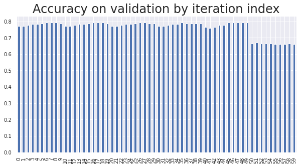

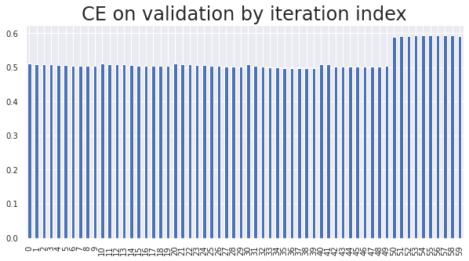

```python
from sklearn import metrics
alpha = [0,1e-4, 1e-3, 1e-2, 1e-1, 1e0]
eta = [0.003,0.006,0.009,0.012,0.015,0.018,0.021,0.024,0.027,0.03]
X_train,X_validation,t_train,t_validation = sklearn.model_selection.train_test_split(train_data, survived_result, test_size=0.2, random_state=2)

i = 0
accArr=[]
ceArr=[]
best_et = 0
best_alp = 0
best_acc = 1
for alp in alpha:
  for et in eta:
    model = linear_model.SGDClassifier(loss='log', alpha=alp, learning_rate='constant',random_state=2, eta0=et)
    model.fit(X_train, t_train)
    y_train_prob = model.predict_proba(X_train)
    y_validation_prob = model.predict_proba(X_validation)

    score = model.score(X_validation, t_validation)
    accArr += [score]
    score = metrics.log_loss(t_validation, y_validation_prob)
    ceArr += [score]

    if score < best_acc:
      best_et = et
      best_alp = alp
      best_acc = score
    '''
    print('Alpha:',alp, " ETA0:", et)
    print('Accuracy score on train', model.score(X_train, t_train))
    print('Accuracy score on validation', model.score(X_validation, t_validation))
    print('CE on train', metrics.log_loss(t_train, y_train_prob))
    print('CE on validation', metrics.log_loss(t_validation, y_validation_prob))
    print("\n--------\n")
    '''
print("Best CE ", best_acc, " Alp ", best_alp, " et ", best_et)

plt.rcParams["xtick.labelsize"] = 10
plt.rcParams["ytick.labelsize"] = 10

pd.DataFrame(accArr).plot.bar(legend=False)
plt.title('Accuracy on validation by iteration index')
plt.show()
pd.DataFrame(ceArr).plot.bar(legend=False)
plt.title('CE on validation by iteration index')
plt.show()


print()
```

# Step 8 - Run model with the parameters found at step 7.5

#### kaggle score was 0.77990

```python
model = linear_model.SGDClassifier(loss='log', alpha=0.01, learning_rate='constant',random_state=2, eta0=0.024)
model.fit(train_data, survived_result)
print('Accuracy score on train', model.score(train_data, survived_result))
preds = model.predict(test_data)
output = pd.DataFrame({'PassengerId': passengerID_forSubmission, 'Survived': preds})
output.to_csv('2nd_model_submission_all2.csv', index=False)
print("Submission CSV was successfully saved!")
```

```
Accuracy score on train 0.8103254769921436
Submission CSV was successfully saved!
```

# My Score

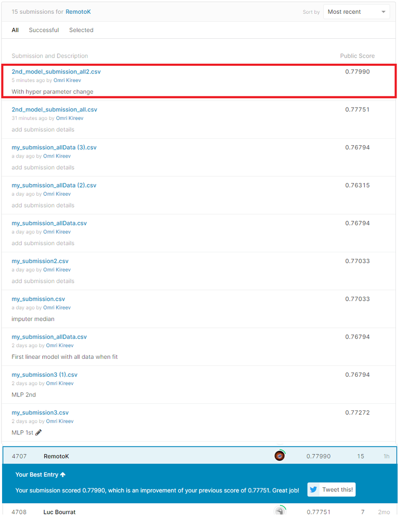

# Summary

At this task I practiced for the first time to use Sklearn libraries.  
I started first by copying a lot of guides and created a pipeline to handle all of the job for me.  
I felt that using the pipeline was cool experience but at the same time I wanted to try the alternate option of transforming my data step by step, thus I recreated my notebook with the prior knowledge I had.

I had trouble understanding what parameters I should change at the SGD model, at the end to my surprise my changing of parameters did in fact help my model score better at kaggle's competition.

I was using some notebooks as refernces here

- First the very helpful introduction to Titanic notebook I found  
  https://www.kaggle.com/alexisbcook/getting-started-with-titanic
- Second I found a very detailed notebook and saw how he did his feature engineering  
  https://www.kaggle.com/gunesevitan/titanic-advanced-feature-engineering-tutorial
- A surprsingly helpful site I found was one about statistics about titanic survivors, that apart from helping me better understand the subjet of the task was really interesting.  
  http://www.icyousee.org/titanic.html

Kaggle's two courses about machine learning were too really helpful.

# -------------------------------------------------

# Exercise 3

```python
# import numpy, matplotlib, etc.
import numpy as np
import pandas as pd
import seaborn as sns
import plotly.express as px
import matplotlib.pyplot as plt
import plotly.graph_objects as go

# sklearn imports
from sklearn import metrics
from sklearn import pipeline
from sklearn import linear_model
from sklearn import preprocessing
from sklearn import neural_network
from sklearn import model_selection
from sklearn.pipeline import Pipeline
from sklearn.pipeline import make_pipeline
from sklearn.feature_selection import RFECV
from sklearn.compose import ColumnTransformer
from sklearn.linear_model import SGDRegressor
from sklearn.linear_model import SGDClassifier
from sklearn.metrics import mean_squared_error
from sklearn.preprocessing import OneHotEncoder
from sklearn.preprocessing import OrdinalEncoder
from sklearn.preprocessing import StandardScaler
from sklearn.model_selection import GridSearchCV
from sklearn.model_selection import RepeatedKFold
from sklearn.linear_model import LinearRegression
from sklearn.neighbors import KNeighborsClassifier
from sklearn.model_selection import cross_val_score
from sklearn.preprocessing import PolynomialFeatures
from sklearn.model_selection import train_test_split
from sklearn.model_selection import KFold
from tqdm.auto import tqdm
```

# As I already did data analysis in exercise 1 I don't really want to remove any features but I'll use Feature Selection to check what is the best features I currently have.

```python
selector = RFECV(SGDClassifier(random_state=1), cv=RepeatedKFold(n_splits=5, n_repeats=5, random_state=1)).fit(train_data, survived_result)
display(train_data_ex3.loc[:, selector.support_])
```

|  | Pclass | SibSp | Parch | Fare | Age_Was_Missing | Sex_female | Sex_male | Embarked_S | Underage | TotalFamily | IsAlone | Age_Squared |
| --- | --- | --- | --- | --- | --- | --- | --- | --- | --- | --- | --- | --- |
| 0 | 3 | 1 | 0 | 7.2500 | 0.0 | 0.0 | 1.0 | 1.0 | 0.0 | 1 | 0.0 | 484.000000 |
| 1 | 1 | 1 | 0 | 71.2833 | 0.0 | 1.0 | 0.0 | 0.0 | 0.0 | 1 | 0.0 | 1444.000000 |
| 2 | 3 | 0 | 0 | 7.9250 | 0.0 | 1.0 | 0.0 | 1.0 | 0.0 | 0 | 1.0 | 676.000000 |
| 3 | 1 | 1 | 0 | 53.1000 | 0.0 | 1.0 | 0.0 | 1.0 | 0.0 | 1 | 0.0 | 1225.000000 |
| 4 | 3 | 0 | 0 | 8.0500 | 0.0 | 0.0 | 1.0 | 1.0 | 0.0 | 0 | 1.0 | 1225.000000 |
| ... | ... | ... | ... | ... | ... | ... | ... | ... | ... | ... | ... | ... |
| 886 | 2 | 0 | 0 | 13.0000 | 0.0 | 0.0 | 1.0 | 1.0 | 0.0 | 0 | 1.0 | 729.000000 |
| 887 | 1 | 0 | 0 | 30.0000 | 0.0 | 1.0 | 0.0 | 1.0 | 0.0 | 0 | 1.0 | 361.000000 |
| 888 | 3 | 1 | 2 | 23.4500 | 1.0 | 1.0 | 0.0 | 1.0 | 0.0 | 3 | 0.0 | 882.037589 |
| 889 | 1 | 0 | 0 | 30.0000 | 0.0 | 0.0 | 1.0 | 0.0 | 0.0 | 0 | 1.0 | 676.000000 |
| 890 | 3 | 0 | 0 | 7.7500 | 0.0 | 0.0 | 1.0 | 0.0 | 0.0 | 0 | 1.0 | 1024.000000 |

891 rows × 12 columns

### I'm actually not surprised to find out that the "Gender" feature was chosen as I already saw this in exercise one -- female were clearly given priority and had a better survival rate.

### As for the Underage feature I could more or less understand that as well as in the third link of my previous exercise I saw a table describing survival rates categorized by age group and I could see there that younger people had a higher survival rate.

### Only 12 features were chosen out of the 15, I thought that I already had too little amount of features maybe some columns have more noise than others.

# I'm intersted to see how good/bad of a model I'll get by keeping only this features.

```python
from sklearn.naive_bayes import MultinomialNB

print('MultinomialNB score of the only 12 features selected above:', cross_val_score(MultinomialNB(), train_data_ex3.loc[:, selector.support_], survived_result, cv=15).mean())
print('MultinomialNB score of all features from my 1st exercise:', cross_val_score(MultinomialNB(), train_data_ex3, survived_result, cv=15).mean())

train_data_ex3 = train_data
test_data_ex3 = test_data
```

```
MultinomialNB score of the only 12 features selected above: 0.6937476459510357
MultinomialNB score of all features from my 1st exercise: 0.6915254237288135
```

### So both scores are not great.

### The model with less features gave me a small improve and I guess it makes training models a bit faster since there is less features but for the duration of this exercise I might I chose to keep all of my original features.

### I chose NBC out of LDA,NBC,KNN, as Gadi didn't teach us LDA I am less familiar with so my real choice was either NBC and KNN I chose NBC because here in this kaggle task we have the target values (Survived/Not Survived) I think that ignoring this information causes us to lose power that we have.

```python
from sklearn.naive_bayes import GaussianNB
from sklearn.decomposition import PCA
from sklearn.metrics import confusion_matrix

model_pipe = Pipeline([('pca', 'passthrough'),
                       ('nbc', GaussianNB())])

hyper_parameters = {'pca': [PCA()],
                    'pca__n_components': list(range(1, len(train_data_ex3.columns)-3))}

gs_model = GridSearchCV(model_pipe, hyper_parameters).fit(train_data_ex3, survived_result)
print('Accuracy score for classification:')
print('gs_model', gs_model.best_score_)
print('best params', gs_model.best_params_)
display(confusion_matrix(survived_result, gs_model.predict(train_data_ex3)))
```

```
Accuracy score for classification:
gs_model 0.7912623187496077
best params {'pca': PCA(copy=True, iterated_power='auto', n_components=7, random_state=None,
    svd_solver='auto', tol=0.0, whiten=False), 'pca__n_components': 7}
```

```
array([[469,  80],
       [103, 239]])
```

```python
preds = gs_model.predict(test_data_ex3)
output = pd.DataFrame({'PassengerId': passengerID_forSubmission, 'Survived': preds})
output.to_csv('3rd_Exercise_NBC.csv', index=False)
print("Submission CSV was successfully saved!")
```

```
Submission CSV was successfully saved!
```

```python
from sklearn.metrics import confusion_matrix
# calculate score and loss from cv (KFold or LPO) and display graphs
def get_cv_score_and_loss(X, t, model, transformer=None, k=None, p=None, show_score_loss_graphs=False, use_pbar=True, averageMatrix=True, printRes=False):
    scores_losses_df = pd.DataFrame(columns=['fold_id', 'split', 'score', 'loss', 'TN', 'FP', 'FN', 'TP'])

    if k is not None:
        cv = KFold(n_splits=k, shuffle=True, random_state=1)
    elif p is not None:
        cv = LeavePOut(p)
    else:
        raise ValueError('you need to specify k or p in order for the cv to work')

    if use_pbar:
        pbar = tqdm(desc='Computing Models', total=find_generator_len(cv.split(X)))

    for i, (train_ids, val_ids) in enumerate(cv.split(X)):
        X_train = X.loc[train_ids]
        t_train = t.loc[train_ids]
        X_val = X.loc[val_ids]
        t_val = t.loc[val_ids]

        model.fit(X_train, t_train)

        y_train = model.predict(X_train)
        y_val = model.predict(X_val)
        tn_train, fp_train, fn_train, tp_train = confusion_matrix(t_train, y_train).ravel()
        tn_val, fp_val, fn_val, tp_val = confusion_matrix(t_val, y_val).ravel()
        scores_losses_df.loc[len(scores_losses_df)] = [i, 'train', model.score(X_train, t_train), metrics.log_loss(t_train, y_train),tn_train, fp_train, fn_train, tp_train]
        scores_losses_df.loc[len(scores_losses_df)] = [i, 'val', model.score(X_val, t_val), metrics.log_loss(t_val, y_val),tn_val, fp_val, fn_val, tp_val]

        if use_pbar:
            pbar.update()

    if use_pbar:
        pbar.close()

    val_scores_losses_df = scores_losses_df[scores_losses_df['split']=='val']
    train_scores_losses_df = scores_losses_df[scores_losses_df['split']=='train']

    mean_val_score = val_scores_losses_df['score'].mean()
    mean_val_loss = val_scores_losses_df['loss'].mean()
    mean_train_score = train_scores_losses_df['score'].mean()
    mean_train_loss = train_scores_losses_df['loss'].mean()
    mean_train_tn = round(train_scores_losses_df['TN'].mean())
    mean_train_fp = round(train_scores_losses_df['FP'].mean())
    mean_train_fn = round(train_scores_losses_df['FN'].mean())
    mean_train_tp = round(train_scores_losses_df['TP'].mean())
    mean_val_tn = round(val_scores_losses_df['TN'].mean())
    mean_val_fp = round(val_scores_losses_df['FP'].mean())
    mean_val_fn = round(val_scores_losses_df['FN'].mean())
    mean_val_tp = round(val_scores_losses_df['TP'].mean())

    if show_score_loss_graphs:
        fig = px.line(scores_losses_df, x='fold_id', y='score', color='split', title=f'Mean Val Score: {mean_val_score:.2f}, Mean Train Score: {mean_train_score:.2f}')
        fig.show()
        fig = px.line(scores_losses_df, x='fold_id', y='loss', color='split', title=f'Mean Val Loss: {mean_val_loss:.2f}, Mean Train Loss: {mean_train_loss:.2f}')
        fig.show()
    if averageMatrix:
      print("Average TN,FP,FN,TP of train")
      print(' {:4d}'.format(mean_train_tn), " | ", '{:4d}'.format(mean_train_fp), "\n", '{:4d}'.format(mean_train_fn), " | ", '{:4d}'.format(mean_train_tp))
      print()
      print("Average TN,FP,FN,TP of val")
      print(' {:4d}'.format(mean_val_tn), " | ", '{:4d}'.format(mean_val_fp), "\n", '{:4d}'.format(mean_val_fn), " | ", '{:4d}'.format(mean_val_tp))
    if printRes:
      print(f'mean cv val score: {mean_val_score:.2f}')
      #print(f'\nmean cv val loss {mean_val_loss:.2f}')
      print(f'mean cv train score: {mean_train_score:.2f}')
      #print(f'\nmean cv train loss {mean_train_loss:.2f}')
    return mean_val_score, mean_val_loss, mean_train_score, mean_train_loss

# find generator length

def find_generator_len(generator, use_pbar=True):
    i = 0

    if use_pbar:
        pbar = tqdm(desc='Calculating Length', ncols=1000, bar_format='{desc}{bar:10}{r_bar}')

    for a in generator:
        i += 1

        if use_pbar:
            pbar.update()

    if use_pbar:
        pbar.close()

    return i
```

# Ensembles

```python
# get score with nfold bagging
from sklearn.ensemble import BaggingClassifier

bag_fold_model = BaggingClassifier(base_estimator=SGDClassifier(), n_estimators=20, random_state=1, bootstrap=False)
bag_fold_model2 = BaggingClassifier(base_estimator=SGDClassifier(), n_estimators=20, random_state=1, bootstrap=True)
get_cv_score_and_loss(train_data_ex3, survived_result, bag_fold_model, k=10, printRes=True)
get_cv_score_and_loss(train_data_ex3, survived_result, bag_fold_model2, k=10, printRes=True)
bag_fold_model = bag_fold_model2.fit(train_data_ex3, survived_result)
print('Accuracy score for classification:')
print('bag_fold_model', bag_fold_model.score(train_data_ex3, survived_result).mean())
preds = bag_fold_model2.predict(test_data_ex3)
output = pd.DataFrame({'PassengerId': passengerID_forSubmission, 'Survived': preds})
output.to_csv('3rd_Exercise_bag_fold.csv', index=False)
print("Submission CSV was successfully saved!")
```

```
Average TN,FP,FN,TP of train
  431  |    63
   88  |   220

Average TN,FP,FN,TP of val
   47  |     8
   10  |    24
mean cv val score: 0.80
mean cv train score: 0.81
```

```
Average TN,FP,FN,TP of train
  431  |    63
   93  |   215

Average TN,FP,FN,TP of val
   48  |     7
   10  |    24
mean cv val score: 0.80
mean cv train score: 0.81
Accuracy score for classification:
bag_fold_model 0.8148148148148148
Submission CSV was successfully saved!
```

### I already knew that there were not a lot of people who survived but after seeing the average TN,FP,FN,TP I think I could actually understand it more.

```python
# get score with ada boosting
from sklearn.ensemble import AdaBoostClassifier

ada_boost_model = AdaBoostClassifier(n_estimators=50, random_state=1).fit(train_data_ex3, survived_result)
print('Accuracy score for classification:')
print('ada_boost_model', ada_boost_model.score(train_data_ex3, survived_result).mean())
display(confusion_matrix(survived_result, ada_boost_model.predict(train_data_ex3)))
preds = ada_boost_model.predict(test_data_ex3)
output = pd.DataFrame({'PassengerId': passengerID_forSubmission, 'Survived': preds})
output.to_csv('3rd_Exercise_ada_boost.csv', index=False)
print("Submission CSV was successfully saved!")
```

```
Accuracy score for classification:
ada_boost_model 0.8327721661054994
```

```
array([[486,  63],
       [ 86, 256]])
```

```
Submission CSV was successfully saved!
```

### I'd like to try Hyperparameter tuning for the AdaBoost classifier

```python
%%time
hyper_parameters = {
    'n_estimators': [50, 100, 200,400, 800],
    'learning_rate': [0.001,0.01,0.1,0.2,0.35,0.5]
}

gridSearch_adaBoost = GridSearchCV(AdaBoostClassifier(random_state=1), param_grid=hyper_parameters).fit(train_data_ex3, survived_result)
print('Accuracy score for classification:')
print('gs_model', gridSearch_adaBoost.best_score_)
print('best params', gridSearch_adaBoost.best_params_)
```

```
Accuracy score for classification:
gs_model 0.8114807607808675
best params {'learning_rate': 0.35, 'n_estimators': 400}
CPU times: user 1min 27s, sys: 258 ms, total: 1min 27s
Wall time: 1min 28s
```

```python
ada_boost_model = AdaBoostClassifier(n_estimators=400, learning_rate=0.35, random_state=1).fit(train_data_ex3, survived_result)
print('Accuracy score for classification:')
print('ada_boost_model', ada_boost_model.score(train_data_ex3, survived_result).mean())
preds = ada_boost_model.predict(test_data_ex3)
output = pd.DataFrame({'PassengerId': passengerID_forSubmission, 'Survived': preds})
output.to_csv('3rd_Exercise_Ada_Boost_parameters.csv', index=False)
print("Submission CSV was successfully saved!")
```

```
Accuracy score for classification:
ada_boost_model 0.8338945005611672
Submission CSV was successfully saved!
```

# Confusion Matrix & KPI

```
array([[481,  68],
       [ 80, 262]])
```

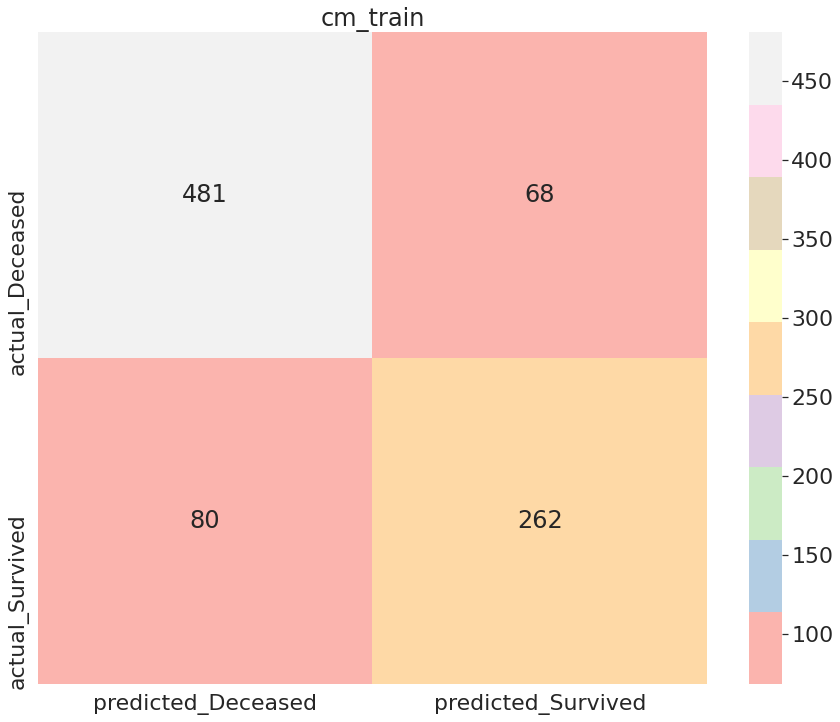

```python
cm_train = confusion_matrix(survived_result, ada_boost_model.predict(train_data_ex3))
display(cm_train)
tn_train, fp_train, fn_train, tp_train = cm_train.ravel()
cm_train_df = pd.DataFrame(cm_train, index=['actual_Deceased', 'actual_Survived'], columns=['predicted_Deceased', 'predicted_Survived'])
sns.set(font_scale=2)
plt.figure(figsize = (15,12))
fig = sns.heatmap(cm_train_df, annot=True, cmap=plt.cm.Pastel1, fmt='g')
fig.set_title("cm_train")
plt.show()
```

### As I can see from the confusion matrix my model has 68 FP which is quite a big number compared to the 262 TP about 1:4

### My TN and FN's ration on the other hand is a bit better at 1:6

```python
# calculate precision, recall, specificity, fpr and accuracy
def precision(cm):
    tn, fp, fn, tp = cm.ravel()
    return tp/(tp+fp)

def recall(cm):
    tn, fp, fn, tp = cm.ravel()
    return tp/(tp+fn)

def specificity(cm):
    tn, fp, fn, tp = cm.ravel()
    return tn/(tn+fp)

def fpr(cm):
    tn, fp, fn, tp = cm.ravel()
    return fp/(fp+tn)

def accuracy(cm):
    tn, fp, fn, tp = cm.ravel()
    return (tp+tn)/(tp+tn+fp+fn)
# calculate f1 and balanced accuracy
def f1(cm):
    precision_calc = precision(cm)
    recall_calc = recall(cm)
    return (2*precision_calc*recall_calc)/(precision_calc+recall_calc)

def balanced_accuracy(cm):
    recall_calc = recall(cm)
    specificity_calc = specificity(cm)
    return (recall_calc+specificity_calc)/2


print(f'Train: precision {precision(cm_train):.2f}, recall {recall(cm_train):.2f}, specificity {specificity(cm_train):.2f}, fpr {fpr(cm_train):.2f}, accuracy {accuracy(cm_train):.2f}')
print(f'Train: f1 {f1(cm_train):.2f}, balanced_accuracy {balanced_accuracy(cm_train):.2f}')
```

```
Train: precision 0.79, recall 0.77, specificity 0.88, fpr 0.12, accuracy 0.83
Train: f1 0.78, balanced_accuracy 0.82
```

# My score did not improve thus I'm only adding a picture of my submission.

[figure not shown]

# Conclusion:

### I had no idea what hyperparameter should I use but I found this site to help me

https://medium.com/swlh/the-hyperparameter-cheat-sheet-770f1fed32ff